# Question

Después de haber comprado un azulejo rectangular, una persona desea colocarlo en la pared de su salón. El azulejo tiene un área de 4.800 cm² y dimensiones de 120 cm de ancho y 40 cm de largo.

Teniendo en cuenta que 1 m equivale a 100 cm, ¿cuál es el área que ocupa el azulejo en m²?

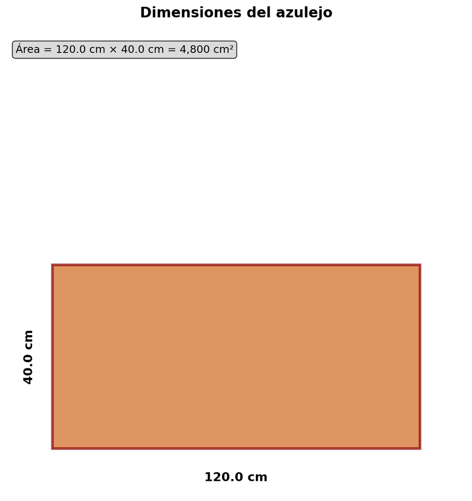

Diagrama del objeto

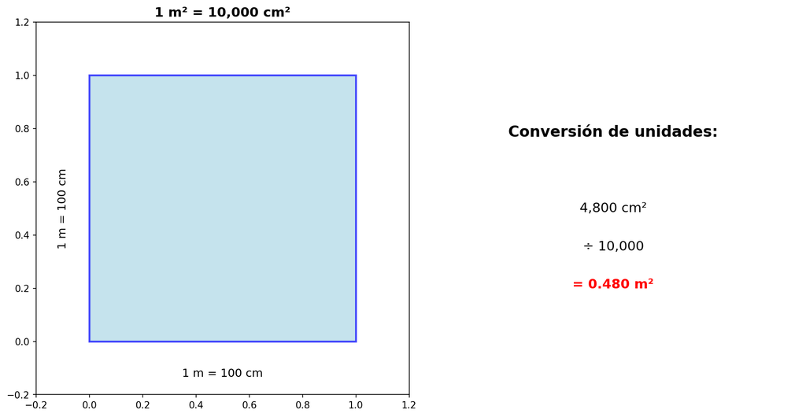

Conversión de unidades

## Answerlist

- 0,48 m²
- 48 m²
- 4,8 m²
- 4.800 m²

# Solution

Para resolver este problema de conversión de unidades de área, debemos recordar la relación entre centímetros cuadrados (cm²) y metros cuadrados (m²).

**Paso 1: Verificar el área dada**

El área del azulejo es 4.800 cm².

Podemos verificar: 120 cm × 40 cm = 4.800 cm²

**Paso 2: Recordar la conversión de unidades**

- 1 m = 100 cm
- Por tanto: 1 m² = 100 cm × 100 cm = 10,000 cm²

**Paso 3: Aplicar la conversión**

Para convertir de cm² a m², debemos dividir entre 10,000:

Área en m² = 4.800 cm² ÷ 10,000 = **0,48 m²**

**Análisis de errores comunes:**

- Si dividimos solo entre 100 (error común al confundir conversión lineal con área): 48 m²
- Si dividimos entre 1,000: 4,8 m²
- Si no convertimos las unidades: 4.800 m² (mantener cm²)

La respuesta correcta es **0,48 m²**.

## Answerlist

- Verdadero. Esta es la conversión correcta: 0,48 m²
- Falso. Error común: dividir solo entre 100 en lugar de 10,000.
- Falso. Conversión incorrecta: dividir entre 1,000.
- Falso. No se realizó la conversión de unidades.

# Meta-information

exname: Conversión de unidades de área - Objetos rectangulares extype: schoice exsolution: 1000 exshuffle: TRUE exsection: Geometría/Conversión de Unidades